# Storm Data Analysis

Xiaotao Qu

February 12, 2016

# 1 Synopsis

preliminary analysis of storm data using controlled event type

# 2 Data Processing

## 2.1 read data in

tried cache and .Rdata to speedy up

```r
#system.time(df<-read.csv("data/repdata-data-StormData.csv",stringsAsFactors = F))
#system.time(saveRDS(df,file="raw.Rdata"))
system.time(df<-readRDS(file="raw.Rdata"))
```

```
##    user  system elapsed
##   8.043   0.150   8.195
```

## 2.2 vocabulary control of event type

### 2.2.1 unique entries in the database

```r
unique_entries<-unique(df$EVTYPE)
```

unique entries in the database is 985

these entries are combination of severnal predifined event type

For example, heavy rain will usually cause flood

### 2.2.2 example of unique event type has “heavy rain” in it

I think they should all combine to one category so I try to apply a controlled vocabulary within limited time

```r
df %>%
  select(EVTYPE) %>%
  filter(grepl("heavy rain",EVTYPE,ignore.case = T)) %>%
  unique() %>%
  head()
```

|  | EVTYPE |
| --- | --- |
| 1 | HEAVY RAIN |
| 3 | HEAVY RAINS |
| 4 | LIGHTNING AND HEAVY RAIN |
| 8 | HEAVY RAIN/LIGHTNING |
| 11 | LIGHTNING/HEAVY RAIN |
| 13 | HIGH WINDS HEAVY RAINS |

### 2.2.3 controled vocabulary borrowed from National Weather Service Storm Data Documentation

https://d396qusza40orc.cloudfront.net/repdata%2Fpeer2_doc%2Fpd01016005curr.pdf

page 6 table 2.1.1 Storm Data Event TAble

given the deadline, manually generated the list to seperate “/” as different event

add “Landslide” as an alternative for “Debris Flow”

```r
data_dict=read.table("Storm_Data_Event_Table.txt",header=T,sep=";")
```

total number of available event type is 53

## 2.3 generate new data table based on controlled vocabulary

### 2.3.1 function that calculate property damage

simple data validation build-in to use values with meaningful EXP term only

```r
Prop_Damage<-function(base,power_of_ten) {
  #print(paste("number is",base))
  #print(paste("power is",power_of_ten))
  #print(typeof(base))
  if (base == 0)
    return(0)
  if (power_of_ten=="B")
    return(base*10^9)
  if (power_of_ten=="K")
    return(base*10^3)
  if (power_of_ten %in% c("M","m"))
    return(base*10^6)
  return(0)
}
```

### 2.3.2 select field of interest and calculate damage as combined property and crops

has weired if statement warning here I can’t figure out how to correct

```r
df.cleaned=df %>%
    select(EVTYPE,FATALITIES,INJURIES,PROPDMG,PROPDMGEXP,CROPDMG,CROPDMGEXP) %>%
    mutate(damage=Prop_Damage(PROPDMG,PROPDMGEXP)+Prop_Damage(CROPDMG,CROPDMGEXP))
```

```
## Warning in if (base == 0) return(0): the condition has length > 1 and only
## the first element will be used
```

```
## Warning in if (power_of_ten == "B") return(base * 10^9): the condition has
## length > 1 and only the first element will be used
```

## 2.4 generate new data.frame with aggregated value

```r
df_result=data.frame()
for(event in data_dict$Event.Name) {
  tmp_df=df.cleaned %>% filter(grepl(event,EVTYPE,ignore.case=T)) %>%
    summarise(event=event,
              total_num=n(),
              fatalities=sum(FATALITIES,na.rm=T),
              injuries=sum(INJURIES),
              damage=sum(damage)
    )
  df_result=rbind(df_result,tmp_df)
}
knitr::kable(head(df_result))
```

| event | total_num | fatalities | injuries | damage |
| --- | --- | --- | --- | --- |
| Astronomical Low Tide | 174 | 0 | 0 | 320000 |
| Avalanche | 387 | 224 | 171 | 1628900 |
| Blizzard | 2745 | 101 | 806 | 26023480 |
| Coastal Flood | 848 | 6 | 7 | 18085990 |
| Cold | 2463 | 451 | 320 | 15171090 |
| Debris Flow | 0 | 0 | 0 | 0 |

# 3 Results

## 3.1 identify data type with NA value

```r
idx_na_row_col=which(is.na(df_result),arr.ind=TRUE)
idx_row=unique(idx_na_row_col[,1])
knitr::kable(df_result[idx_row,])
```

[output not shown]

## 3.2 Which types of events are most harmful with respeiot to population health?

Use death and/or injury per 100 event as indicator of population health for this project

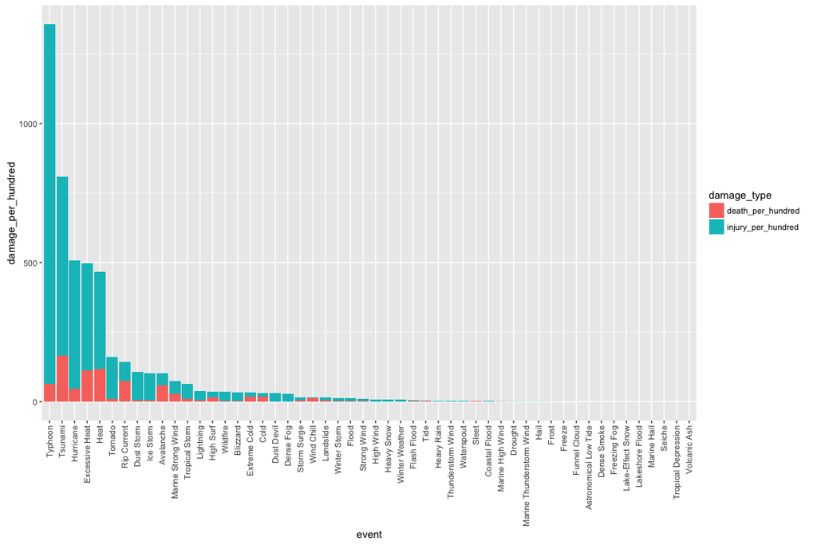

```r
df_result<-df_result %>%
  mutate(death_per_hundred=fatalities/total_num*100,
        injury_per_hundred=injuries/total_num*100
  )

#order data by total heath impact
position=arrange(na.omit(df_result),-(death_per_hundred+injury_per_hundred))$event

#slim the data for plot
df_plot=na.omit(df_result) %>%
  gather(damage_type,damage_per_hundred,death_per_hundred:injury_per_hundred)


ggplot(df_plot, aes(event,damage_per_hundred,fill=damage_type)) +
  geom_bar(stat="identity")+
  scale_x_discrete(limits=position) +
  theme(axis.text.x=element_text(angle=90,hjust=1,vjust=0.5))
```

## 3.3 which types of events have the greatest economic consequences?

use averaged damage per event as indicator

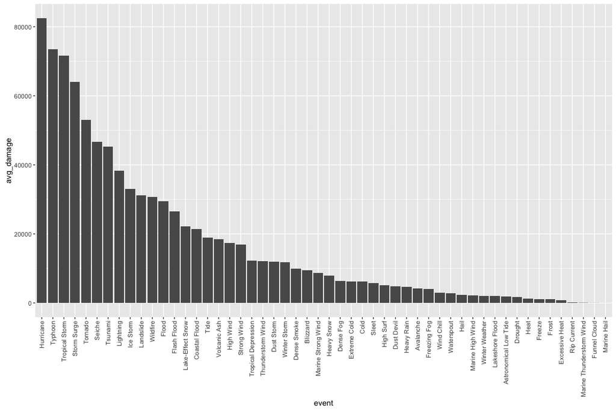

```r
df_result<-df_result %>%
  mutate(avg_damage=damage/total_num)

#order data by averaged damage
position=arrange(na.omit(df_result),-(avg_damage))$event

ggplot(na.omit(df_result), aes(event,avg_damage)) +
  geom_bar(stat="identity")+
  scale_x_discrete(limits=position) +
  theme(axis.text.x=element_text(angle=90,hjust=1,vjust=0.5))
```